# Main

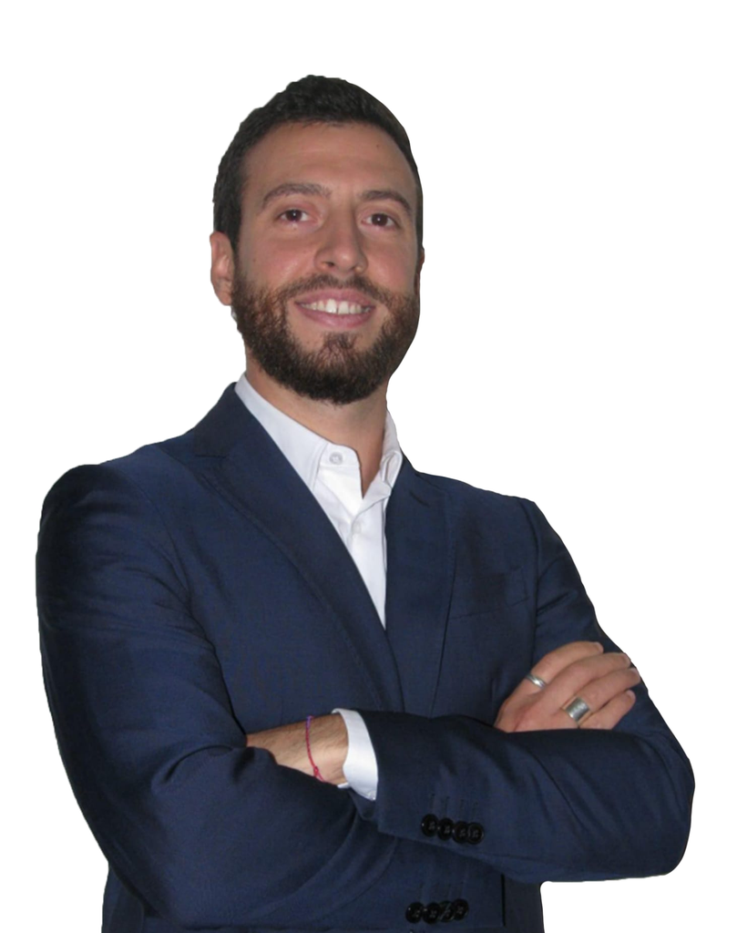

#### Contacts

- [marcozanotti](https://marcozanotti.netlify.app/)
- zanottimarco17@gmail.com
- [gh-marcozanotti](https://github.com/marcozanotti)
- [lk-marcozanotti](https://www.linkedin.com/in/marco-zanotti-a6a978124/)
- +39 334 9808108

#### Core Skills

High experience in time series modeling and forecasting, ML modeling and text mining

#### Languages

Italian

English

French

## Marco Zanotti

I am a machine learning engineer and data scientist with broad knowledge in time series analysis, forecasting, anomaly detection, and econometrics.  
I specialized in developing and enhancing business forecasting processes and practices. Over the years I developed and contributed to core forecasting systems in sectors like e-commerce fashion, airline, tourism and travel. I also guided and mentored junior colleagues in developing predictive models that enable accurate forecasting.  
I am passionate about advancing the field of forecasting and fostering collaboration between academia and industry. I do academic work in forecasting, and I am a member of the International Institute of Forecasters.  
Recently I have enjoyed teaching professionals and university students about time series analysis, machine learning, programming, and statistics.

## Professional Experience

### Ph.D. Student, Statistics

University of Milano-Bicocca

Milan, Italy

current - 2022

- Research on time series forecasting, cross-learning, forecasting stability, time series foundation models (LLMs), and sustainable AI

### Data Scientist, Forecasting Specialist

Wanan Luxury - E-commerce Fashion - Full remote

Rome, Italy

2024 - 2024

- Led the company’s time series forecasting projects
- Coordinated and contributed to the development of a forecasting tool to predict future demand for tens of thousands item-level (SKUs) time series across several markets worldwide, and with different product hierarchies, resulting in increased forecasting accuracy and efficiency
- Integrated probabilistic methods to support more informed inventory decisions
- Designed and developed an app for evaluating forecasting experiments, enhancing reliability of the analyses
- Provided mentorship to junior colleagues, supporting their professional growth and development in the field of forecasting

### Data Scientist

Blogmeter - Digital Services - Hybrid

Milan, Italy

2024 - 2021

- Integrated machine learning solutions into the main applications of the company
- Developed an anomaly detection solution to promptly communicate relevant events to the clients
- Coordinated the Product team

### Data Scientist

T-Voice - Digital Services - Full remote

Milan, Italy

2021 - 2020

- Contributed to the development of an AI platform for the analysis of textual data
- Effectively incorporated text data into forecasting models
- Coordinated the R&D team

### Junior Data Scientist

Uvet Amex GBT - Tourism and Aviation - Hybrid

Milan, Italy

2020 - 2017

- Developed and maintained diverse statistical and machine learning models to predict: sales at different aggregations to support strategic decisions; daily inbound calls to optimize scheduling hours; air passenger demand over several destinations to support aircraft planning; business car rental demand to support fleets management
- Successfully improved the approach to forecasting, resulting in a significant reduction of errors and facilitating the faster adoption of machine learning solutions by the business
- Implemented an anomaly detection system to signal possible congestions in the company’s reservation systems
- Developed econometric models to measure key drivers of business travel and tourism
- Supported automation processes implementing OCR solutions

#### Programming

R

Python

Bash

#### BI & Visualization

Shiny

#### Databases

SQL

InfluxDB

MySQL

PostgreSQL

Big Query

#### Versioning

Git

GitHub

GitLab

BitBucket

#### CI / CD

GitHub Actions

Codecov

Jenkins

#### Cloud

Google Cloud Platform

Amazon Web Services

#### Project Management

Jira

Asana

#### Operating Systems

Linux

## Teaching Experience

### Adjunct Professor

University of Milan - Hybrid

N/A

current - 2019

I teach modern time series forecasting, machine learning, coding, and statistics.

## Publications

### [On the retraining frequency of global models in retail demand forecasting](https://doi.org/10.1016/j.mlwa.2025.100769)

University of Milano-Bicocca

N/A

2025

### [The effects of retraining on the stability of global models in retail demand forecasting.](https://doi.org/10.48550/arXiv.2506.05776)

University of Milano-Bicocca

N/A

2025

### [The cost of ensembling: Is it always worth combining?](https://doi.org/10.48550/arXiv.2506.04677)

University of Milano-Bicocca

N/A

2025

### [dispositionEffect](https://cloud.r-project.org/web/packages/dispositionEffect/index.html)

CRAN, R Software

N/A

2021

#### Certificates

• [Certified Forecaster and Demand Planner](https://drive.google.com/file/d/15qr9q6Gn-Hmm0o7oq3du6LZgshwrFgek/view?usp=drive_link), ISCEA

• [High-Performance Time Series Forecasting](https://drive.google.com/file/d/1ErHw9P9oDdKJbYXgqbDXyQM9PTKXkGSm/view?usp=drive_link), BS University

• [Time Series Analysis](https://drive.google.com/file/d/1-d6Skr9B-mGaDpPUWGSS68M3QXEhRHRk/view?usp=sharing), CAC IIT

• [Deep Learning for Sequence Modelling and Times Series](https://drive.google.com/drive/folders/1WXFi4qIBkNqcuxQ6sMY0v2HesR7cgTM-), Deep Learning Italia

• [Python for Machine Learning and APIs](https://drive.google.com/file/d/1DbvWrhzYpVcDLJoGQ7LO7_IwXAzC6fSc/view?usp=drive_link), BS University

• [Python for Data Science Automation](https://drive.google.com/file/d/1gP5gSPn510HiWyLMFkecp_i2TLLQ2pl-/view?usp=drive_link), BS University

• [Shiny Web Applications](https://drive.google.com/file/d/1qTFvQdoRIPFuH92njxA6__t1tGFSHP4T/view?usp=drive_link), BS University

• [Macroeconometric Foreasting](https://drive.google.com/file/d/1dpgNe8ScxJKVrkEFWI-qgg8-5c4TqBPi/view?usp=drive_link), IMF

#### Spoorts & Hobbies

I was a footballer. I played in Italian minor championships until 22.  
Now I practice kitesurf, an amazing waterboard sport, and I do canicross with my little friend Milo.

I like manga, boardgames, videogames, curling and footgolf. I love listening folk and country music.

## Awards

### [IIF-SAS Forecasting Research Grant](https://forecasters.org/programs/research-awards/iif-sas/)

International Institute of Forecasters - SAS

N/A

2025

### International Symposium on Forecasting Award

International Institute of Forecasters

Beijin, China

2025

## Conferences & Seminars

### Do global forecasting models require frequent retraining?

International Symposium on Forecasting

Beijin, China

2025

### Computing Disposition Effect on Financial Market Data

useR! 2021 Conference

Remote

2021

## Education

### Ph.D., Statistics

University of Milano-Bicocca

Milan, Italy

current - 2022

Research on time series forecasting, cross-learning, forecasting stability, time series foundation models (LLMs), and sustainable AI

### Post-graduate, Data Science for Economics, Business and Finance

University of Milan

Milan, Italy

2018

### M.Sc., Economics and Finance

University of Milan

Milan, Italy

2017 - 2015

### B.Sc., Political Sciences and International Relations

University of Parma  
ERASMUS, University of Lapland, Rovaniemi, Finland

Parma, Italy

2014 - 2011

Made with R and [**pagedown**](https://github.com/rstudio/pagedown)

*Last updated on* *December 2025*

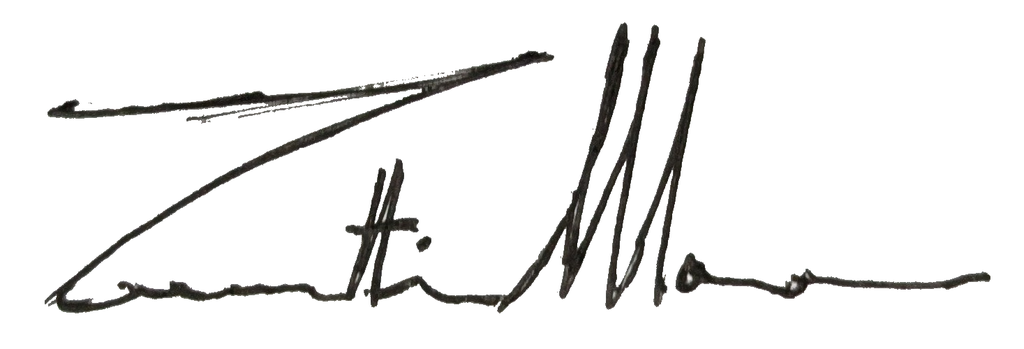

## Personal Competences

### Organisational and Management

- Project management: I coordinated the development of different projects, from analysis to implementation
- People management: I coordinated the activities of junior colleagues, supervising and guiding in their professional develpment
- High relational and communication skills
- High resistance to stress
- Since 2020 I proficiently work from remote